# Midterm Make-up Questions

Biostat 200C

Author

Dr. Jin Zhou @ UCLA

Published

June 5, 2024

# 1 Count Data Example - Microbiome (60 pts)

## 1.1 Introduction

- This data package contains the information used to run the analyses found in “[Diarrhea in young children from low-income countries leads to large-scale alterations in intestinal microbiota composition](https://genomebiology.biomedcentral.com/articles/10.1186/gb-2014-15-6-r76)”.
- Measurements are the number of reads annotated for a particular cluster within a given sample followed by filtering. Sequencing was performed on the 454 Flex platform.
- Data is stored as an `MRexperiment-class` object. The count matrix was generated using DNAclust (http://dnaclust.sourceforge.net/). For more details please refer to the paper. Included in the `MRexperiment` object are the counts, phenotype, and feature information.

## 1.2 Microbiome data background

- The human microbiome is the collection of all the microorganisms living in association with the human body. These communities consist of a variety of microorganisms including eukaryotes, archaea, bacteria, and viruses.
- The human body, consisting of about 10 trillion cells, carries about ten times as many microorganisms in the intestines. The metabolic activities performed by these bacteria resemble those of an organ, leading some to liken gut bacteria to a “forgotten” organ.
- Hight-throughput sequencing technologies have enabled the study of the human microbiome through the use of metagenomic data.
  - OTU (Operational Taxonomic Unit) is a cluster of sequences that are at least 97% similar. OTUs are used to classify sequences into groups that are similar to each other.
  - OTU counts are used to represent the abundance of each OTU in each sample.
  - OTU counts can be aggregated at higher phylogentic levels, e.g., species, genus, etc.
  - The higher the level the less zero-inflated the data is.

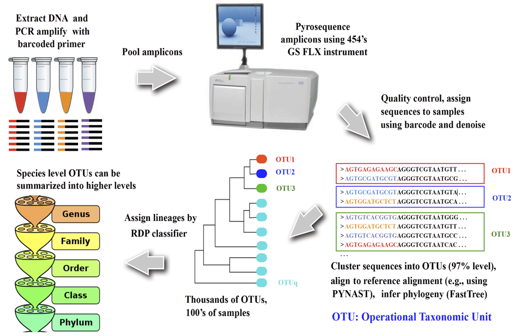

- Features of microbiome data include
  - Zero-inflated: many OTUs are not observed in many samples
  - Overdispersed: the variance is larger than the mean
  - Compositional: the sum of all OTUs in a sample is constant
  - High-dimensional: large number of OTUs

## 1.3 Goal of this excercise

- One goal of microbiome data analysis is to identify the association between microbiome composition and clinical outcomes. In this study, it is case-control status: diarrhea vs non-diarrhea.
- Try the techniques we learned so far to analyze the microbiome data, at genus and species levels, to identify the association between microbiome composition and case-control status. Use the following models:
  - Quasi-Poisson
  - Negative Binomial
  - Zero Inflated Poisson
  - Zero Inflated Negative Binomial

### 1.3.1 Question 1

- Compare the results from these models and discuss the pros and cons of each model.
  - Create a table to summarize the significant microbiome clusters from these models.

```r
tibble::tibble(
  Model = c("Quasi-Poisson", "Negative Binomial", "Zero Inflated Poisson", "Zero Inflated Negative Binomial"),
  Significant = c(0, 0, 0, 0)
)
```

```
# A tibble: 4 × 2
  Model                           Significant
  <chr>                                 <dbl>
1 Quasi-Poisson                             0
2 Negative Binomial                         0
3 Zero Inflated Poisson                     0
4 Zero Inflated Negative Binomial           0
```

- Create a Venn Diagram to summarize the significant microbiome clusters overlaps from these models.

### 1.3.2 Question 2

- Evaluate empirical type I error rate of the methods adopted in this study for 41 genus and 101 species.
  - Example code provided below.
  - Summarize your median (IQR) of the type I error across genus and species in a table.

```r
tibble::tibble(
  Method = c("Quasi-Poisson", "Negative Binomial", "Zero Inflated Poisson", "Zero Inflated Negative Binomial"),
  Genus = c("0 IQR()" , "0 IQR()", "0 IQR()", "0 IQR()"),
  Species = c("0 IQR()", "0 IQR()", "0 IQR()", "0 IQR()")
)
```

```
# A tibble: 4 × 3
  Method                          Genus   Species
  <chr>                           <chr>   <chr>
1 Quasi-Poisson                   0 IQR() 0 IQR()
2 Negative Binomial               0 IQR() 0 IQR()
3 Zero Inflated Poisson           0 IQR() 0 IQR()
4 Zero Inflated Negative Binomial 0 IQR() 0 IQR()
```

### 1.3.3 Question 3

- Comment on the model fit (Question 1) of different models using, for example, AIC, etc., the control type I error rate, and Summarize esults from the best model.

## 1.4 Example code

### 1.4.1 Load required packages

```r
# if (!require("BiocManager", quietly = TRUE))
#    install.packages("BiocManager")
# BiocManager::install("msd16s")

# BiocManager::install("metagenomeSeq")
suppressMessages(library(metagenomeSeq))
library(msd16s)
library(tidyverse)
library(broom)
```

### 1.4.2 Load data and process

```r
data(msd16s)
msd16s
```

```
MRexperiment (storageMode: environment)
assayData: 26044 features, 992 samples
  element names: counts
protocolData: none
phenoData
  sampleNames: 100259 100262 ... 602385 (992 total)
  varLabels: Type Country ... Dysentery (5 total)
  varMetadata: labelDescription
featureData
  featureNames: 54 94 ... 276421 (26044 total)
  fvarLabels: superkingdom phylum ... clusterCenter (10 total)
  fvarMetadata: labelDescription
experimentData: use 'experimentData(object)'
Annotation:
```

The phenotype information can be accessed with the phenoData and pData methods:

```r
phenoData(msd16s)
```

```
An object of class 'AnnotatedDataFrame'
  sampleNames: 100259 100262 ... 602385 (992 total)
  varLabels: Type Country ... Dysentery (5 total)
  varMetadata: labelDescription
```

```r
pheno_tbl <- rownames_to_column(pData(msd16s), var = "ID") %>% as_tibble()
pheno_tbl
```

```
# A tibble: 992 × 6
   ID     Type    Country   Age AgeFactor Dysentery
   <chr>  <chr>   <fct>   <dbl> <fct>         <dbl>
 1 100259 Case    Gambia     14 [12,18)           1
 2 100262 Control Gambia     24 [24,60)           0
 3 100267 Case    Gambia     17 [12,18)           0
 4 100274 Case    Gambia     36 [24,60)           0
 5 100275 Case    Gambia     29 [24,60)           0
 6 100277 Case    Gambia     29 [24,60)           0
 7 100291 Control Gambia     27 [24,60)           0
 8 100292 Control Gambia     30 [24,60)           0
 9 100293 Case    Gambia     20 [18,24)           1
10 100294 Control Gambia     33 [24,60)           0
# ℹ 982 more rows
```

```r
p_case_control = pheno_tbl %>%
  count(Type) %>%
  mutate(prop = n/sum(n))

p_case <- with(p_case_control, prop[Type == "Case"])
p_control <- with(p_case_control, prop[Type == "Control"])
```

- The feature information including cluster representative (e.g., OTUs) sequence can be accessed with the featureData and fData methods:

```r
featureData(msd16s)
```

```
An object of class 'AnnotatedDataFrame'
  featureNames: 54 94 ... 276421 (26044 total)
  varLabels: superkingdom phylum ... clusterCenter (10 total)
  varMetadata: labelDescription
```

```r
features <- fData(msd16s)
```

```r
counts <- MRcounts(msd16s, norm = TRUE)
dim(counts)
```

```
[1] 26044   992
```

The raw or normalized counts matrix can be accessed with the MRcounts function. We get normalized counts. A normalization method avoids biases due to uneven sequencing depth.

```r
otu_id <- rownames(counts)
counts_tbl <- bind_cols(otu_id = otu_id, counts %>% as_tibble())
counts_tbl
```

```
# A tibble: 26,044 × 993
   otu_id `100259` `100262` `100267` `100274` `100275` `100277` `100291`
   <chr>     <dbl>    <dbl>    <dbl>    <dbl>    <dbl>    <dbl>    <dbl>
 1 54            0        0        0        0        0        0        0
 2 94            0        0        0        0        0        0        0
 3 113           0        0        0        0        0        0        0
 4 117           0        0        0        0        0        0        0
 5 145           0        0        0        0        0        0        0
 6 202           0        0        0        0        0        0        0
 7 217           0        0        0        0        0        0        0
 8 237           0        0        0        0        0        0        0
 9 245           0        0        0        0        0        0        0
10 248           0        0        0        0        0        0        0
# ℹ 26,034 more rows
# ℹ 985 more variables: `100292` <dbl>, `100293` <dbl>, `100294` <dbl>,
#   `100298` <dbl>, `100303` <dbl>, `100317` <dbl>, `100320` <dbl>,
#   `100322` <dbl>, `100341` <dbl>, `100353` <dbl>, `100356` <dbl>,
#   `100361` <dbl>, `100365` <dbl>, `100395` <dbl>, `100401` <dbl>,
#   `100403` <dbl>, `100437` <dbl>, `100457` <dbl>, `100462` <dbl>,
#   `100470` <dbl>, `100476` <dbl>, `100489` <dbl>, `100491` <dbl>, …
```

#### 1.4.2.1 Filter data at OTU level

- OTU was abundant (≥12 normalized counts per sample) in cases or controls;

```r
control_to_select <- pheno_tbl %>%
  filter(Type == "Control") %>%
  dplyr::select(ID) %>%
  pull()

con_sum <- counts_tbl %>%
  dplyr::select(all_of(control_to_select)) %>%
  rowSums()

case_to_select <- pheno_tbl %>%
  filter(Type == "Case") %>%
  dplyr::select(ID) %>%
  pull()

case_sum <- counts_tbl %>%
  dplyr::select(all_of(case_to_select)) %>%
  rowSums()

counts_tbl_filt <- bind_cols(counts_tbl,
                             con_sum = con_sum/length(control_to_select),
                             case_sum = case_sum/length(case_to_select)) %>%
  filter(con_sum >= 12 | case_sum >= 12)
```

- OTU was prevalent (present in ≥10 cases and controls);

```r
otu_prevalence <- counts_tbl_filt %>%
  dplyr:: select(-otu_id) %>%
  mutate(across(everything(), ~ as.integer(. > 0))) %>%
  rowSums()

counts_tbl <- bind_cols(counts_tbl_filt, otu_prevalence = otu_prevalence) %>%
  filter(otu_prevalence >= 10) %>%
  dplyr:: select(-con_sum, -case_sum, -otu_prevalence)
```

```r
counts_tbl_t <- counts_tbl %>%
  pivot_longer(cols= -1) %>%
  pivot_wider(names_from = "otu_id",values_from = "value") %>%
  rename(ID = name) %>%
  left_join(pheno_tbl, by = "ID")
```

#### 1.4.2.2 Filter data at Genus level

- Aggregated counts at genus level

```r
genus_counts = aggTax(msd16s, lvl = "genus", out = "matrix", norm = T)
genus_id <- rownames(genus_counts)
genus_counts_tbl <- bind_cols(genus_id = genus_id, genus_counts %>% as_tibble())
genus_counts_tbl
```

```
# A tibble: 164 × 993
   genus_id       `100259` `100262` `100267` `100274` `100275` `100277` `100291`
   <chr>             <dbl>    <dbl>    <dbl>    <dbl>    <dbl>    <dbl>    <dbl>
 1 Abiotrophia         0          0     0         0          0     0        1.80
 2 Acetobacter         0          0     0         0          0     0        0
 3 Acetonema           0          0     0         0          0     0        0
 4 Acidaminococc…     10.6        0     0        73.9        0    80.7      0
 5 Acidithiobaci…      0          0   141.        0          0     0        0
 6 Acidovorax          0          0     0         0          0     0        0
 7 Acinetobacter       0          0     0         0          0     2.60     0
 8 Actinobacillus      0          0     0         0          0     0        0
 9 Actinomyces        19.4        0     1.79      0          0     0        0
10 Aeromonas           0          0     0         0          0     0        0
# ℹ 154 more rows
# ℹ 985 more variables: `100292` <dbl>, `100293` <dbl>, `100294` <dbl>,
#   `100298` <dbl>, `100303` <dbl>, `100317` <dbl>, `100320` <dbl>,
#   `100322` <dbl>, `100341` <dbl>, `100353` <dbl>, `100356` <dbl>,
#   `100361` <dbl>, `100365` <dbl>, `100395` <dbl>, `100401` <dbl>,
#   `100403` <dbl>, `100437` <dbl>, `100457` <dbl>, `100462` <dbl>,
#   `100470` <dbl>, `100476` <dbl>, `100489` <dbl>, `100491` <dbl>, …
```

- Genus was abundant (≥12 normalized counts per sample) in cases or controls;

```r
con_mean <- genus_counts_tbl %>%
  dplyr:: select(all_of(control_to_select)) %>%
  rowMeans()

case_mean <- genus_counts_tbl %>%
  dplyr:: select(all_of(case_to_select)) %>%
  rowMeans()

genus_tbl_filt <- bind_cols(genus_counts_tbl,
                             con_mean = con_mean,
                             case_mean = case_mean) %>%
  filter(con_mean >= 12 | case_mean >= 12)
```

- Genus was prevalent (present in ≥10 cases and controls);

```r
otu_prevalence <- genus_tbl_filt %>%
  dplyr:: select(-genus_id) %>%
  mutate(across(everything(), ~ as.integer(. > 0))) %>%
  rowSums()

genus_tbl <- bind_cols(genus_tbl_filt, otu_prevalence = otu_prevalence) %>%
  filter(otu_prevalence >= 10) %>%
  dplyr:: select(-con_mean, -case_mean, -otu_prevalence) %>%
  filter(genus_id != "NA")

rm(genus_tbl_filt)

genusnames = genus_tbl$genus_id
```

- Create a tidy table with pheno information

```r
genus_tbl_t <- genus_tbl %>%
  pivot_longer(cols= -1) %>%
  pivot_wider(names_from = "genus_id",values_from = "value") %>%
  rename(ID = name) %>%
  left_join(pheno_tbl, by = "ID")  # %>%
  #dplyr::select(-`NA`)
```

#### 1.4.2.3 Filter data at Species level

```r
species_counts = aggTax(msd16s, lvl = "species", out = "matrix", norm = T)
species_id <- rownames(species_counts)
species_counts_tbl <- bind_cols(species_id = species_id, species_counts %>% as_tibble())
species_counts_tbl
```

```
# A tibble: 754 × 993
   species_id     `100259` `100262` `100267` `100274` `100275` `100277` `100291`
   <chr>             <dbl>    <dbl>    <dbl>    <dbl>    <dbl>    <dbl>    <dbl>
 1 [Leptotrichia…      0          0       0       0          0      0       0
 2 Abiotrophia d…      0          0       0       0          0      0       1.80
 3 Acetobacter i…      0          0       0       0          0      0       0
 4 Acetobacter s…      0          0       0       0          0      0       0
 5 Acetonema lon…      0          0       0       0          0      0       0
 6 Acidaminococc…     10.6        0       0      73.9        0     80.7     0
 7 Acidaminococc…      0          0       0       0          0      0       0
 8 Acidithiobaci…      0          0     141.      0          0      0       0
 9 Acidithiobaci…      0          0       0       0          0      0       0
10 Acidovorax ca…      0          0       0       0          0      0       0
# ℹ 744 more rows
# ℹ 985 more variables: `100292` <dbl>, `100293` <dbl>, `100294` <dbl>,
#   `100298` <dbl>, `100303` <dbl>, `100317` <dbl>, `100320` <dbl>,
#   `100322` <dbl>, `100341` <dbl>, `100353` <dbl>, `100356` <dbl>,
#   `100361` <dbl>, `100365` <dbl>, `100395` <dbl>, `100401` <dbl>,
#   `100403` <dbl>, `100437` <dbl>, `100457` <dbl>, `100462` <dbl>,
#   `100470` <dbl>, `100476` <dbl>, `100489` <dbl>, `100491` <dbl>, …
```

- Species was abundant (≥12 normalized counts per sample) in cases or controls;

```r
con_mean <- species_counts_tbl %>%
  dplyr:: select(all_of(control_to_select)) %>%
  rowMeans()

case_mean <- species_counts_tbl %>%
  dplyr:: select(all_of(case_to_select)) %>%
  rowMeans()

species_tbl_filt <- bind_cols(species_counts_tbl,
                             con_mean = con_mean,
                             case_mean = case_mean) %>%
  filter(con_mean >= 12 | case_mean >= 12)
```

```r
otu_prevalence <- species_tbl_filt %>%
  dplyr:: select(-species_id) %>%
  mutate(across(everything(), ~ as.integer(. > 0))) %>%
  rowSums()

species_tbl <- bind_cols(species_tbl_filt, otu_prevalence = otu_prevalence) %>%
  filter(otu_prevalence >= 10) %>%
  dplyr:: select(-con_mean, -case_mean, -otu_prevalence)

rm(species_tbl_filt)
speciesnames = species_tbl$species_id[-1*which(species_tbl$species_id == "NA")]
```

- Create a tidy table with pheno information

```r
species_tbl_t <- species_tbl %>%
  pivot_longer(cols= -1) %>%
  pivot_wider(names_from = "species_id",values_from = "value") %>%
  rename(ID = name) %>%
  left_join(pheno_tbl, by = "ID") %>%
  dplyr:: select(-`NA`)
```

### 1.4.3 Differential abundance analysis

#### 1.4.3.1 Genus level

- Quasipoisson regression model

```r
results_genus_qpoisson <-
  map_df(genusnames, function(response) {
    model <- glm(as.formula(paste(response, "~ Type")),
                 data = genus_tbl_t,
                 family = quasipoisson)
    tidy(model, conf.int = TRUE) %>%
      # Add a column for the response variable
      mutate(response_variable = response)
    }) %>%
  filter(term == "TypeControl") %>%
  arrange(p.value)

results_genus_qpoisson %>% filter(p.value < 0.05/41) %>%
  dplyr::select(response_variable, p.value) %>%
  print(n = 20)
```

```
# A tibble: 12 × 2
   response_variable  p.value
   <chr>                <dbl>
 1 Escherichia       1.67e-17
 2 Prevotella        6.43e-16
 3 Streptococcus     8.92e-12
 4 Haemophilus       4.33e- 9
 5 Granulicatella    1.78e- 7
 6 Eubacterium       3.26e- 7
 7 Lactobacillus     2.69e- 6
 8 Enterobacter      3.70e- 6
 9 Shigella          9.08e- 6
10 Bacteroides       1.02e- 5
11 Neisseria         2.10e- 4
12 Rothia            8.74e- 4
```

- Negative binomial regression model

```r
library(MASS)


results_genus_nb2 <-
  map_df(genusnames, function(response) {
  #  print(response)
    model <- glm(as.formula(paste(response, "~ Type")),
                 family = negative.binomial(20),
                 data = genus_tbl_t)
    tidy(model, conf.int = TRUE) %>%
      # Add a column for the response variable
      mutate(response_variable = response)
    }) %>%
  filter(term == "TypeControl") %>%
  arrange(p.value)

results_genus_nb2 %>% filter(p.value < 0.05/41) %>%
  dplyr::select(response_variable, p.value) %>%
  print(n = Inf)
```

```
# A tibble: 17 × 2
   response_variable  p.value
   <chr>                <dbl>
 1 Escherichia       1.80e-21
 2 Streptococcus     1.19e-16
 3 Haemophilus       4.72e-16
 4 Prevotella        1.22e-15
 5 Granulicatella    3.85e-11
 6 Eubacterium       1.11e- 7
 7 Lactobacillus     1.72e- 7
 8 Enterobacter      1.96e- 6
 9 Shigella          3.67e- 6
10 Bacteroides       4.00e- 6
11 Neisseria         8.11e- 6
12 Blautia           1.03e- 4
13 Weissella         1.51e- 4
14 Campylobacter     4.08e- 4
15 Rothia            5.75e- 4
16 Acinetobacter     1.09e- 3
17 Sarcina           1.11e- 3
```

#### 1.4.3.2 Species level

- Quasipoisson regression model

```r
results_species_qpoisson <-
  map_df(names(species_tbl_t)[2:102], function(response) {
    model <- glm(as.formula(paste("`", response, "`", "~ Type", sep = "")),
                 data = species_tbl_t,
                 family = quasipoisson)
    tidy(model, conf.int = TRUE) %>%
      # Add a column for the response variable
      mutate(response_variable = response)
    }) %>%
  filter(term == "TypeControl") %>%
  arrange(p.value)

results_species_qpoisson %>%
  filter(p.value < 0.05/102) %>%
  dplyr::select(response_variable, p.value) %>%
  print(n = 20)
```

```
# A tibble: 20 × 2
   response_variable                    p.value
   <chr>                                  <dbl>
 1 Escherichia coli                    1.71e-17
 2 Prevotella copri                    1.89e-11
 3 Prevotella sp. DJF_B112             7.02e-11
 4 Prevotella sp. DJF_RP53             5.24e- 9
 5 Prevotella sp. oral clone BP1-28    4.53e- 8
 6 Haemophilus parainfluenzae          3.03e- 7
 7 Acinetobacter sp. SF6               3.06e- 7
 8 Enterobacter cloacae                4.05e- 7
 9 Prevotella sp. BI-42                1.19e- 6
10 Streptococcus sp. oral clone ASCC04 1.30e- 6
11 Streptococcus peroris               7.89e- 6
12 Streptococcus mitis                 9.02e- 6
13 Streptococcus sp. C101              1.78e- 5
14 Streptococcus equinus               8.94e- 5
15 Streptococcus salivarius            9.86e- 5
16 Streptococcus sp. oral clone ASCE09 1.94e- 4
17 Prevotella sp. DJF_B116             2.08e- 4
18 Bacteroides fragilis                2.59e- 4
19 Megasphaera elsdenii                3.05e- 4
20 Eubacterium rectale                 4.56e- 4
```

- Negative binomial regression model

```r
results_species_nb2 <-
  map_df(speciesnames, function(response) {
    # print(response)
    model <- glm(as.formula(paste("`", response, "`", "~ Type", sep = "")),
                 family = negative.binomial(20),
                 data = species_tbl_t)
    tidy(model, conf.int = TRUE) %>%
      # Add a column for the response variable
      mutate(response_variable = response)
    }) %>%
  filter(term == "TypeControl") %>%
  arrange(p.value)
```

### 1.4.4 Evaluate Type I Error rate

- This section evaluates the Type I error rate of the models by simulating data under the null hypothesis of no association between the microbiome and the outcome variable.
- We simulate binary labels 100 times using a Bernoulli distribution with a probability of 0.512 (estimated from the data) for each sample.
- We evaluate the association between each genus and the outcome variable using different regression models, document the proportion of significant associations using threshold of 0.05 over 100 replicates (e.g., empirical type I error).
- We repeat the same process for the species level data.
- If the empirical type I error rate is close to the nominal type I error rate (0.05), then the model is considered to have good control over the Type I error rate.
- If the empirical type I error rate is much lower than the nominal type I error rate, then the model is considered to be conservative.
- If the empirical type I error rate is much higher than the nominal type I error rate, then the model is considered to be inflated (i.e., false positive rate is higher than expected).

#### 1.4.4.1 Genus level

- Quasipoisson regression model

```r
# Set the number of columns
num_columns <- 100
num_rows <- dim(genus_tbl_t)[1]
set.seed(10)

# Generate the tibble with 100 columns of random normal values
type1e <- function(genusname) {
  sim_tbl <- tibble(
    y = genus_tbl_t %>% dplyr::select(all_of(genusname)) %>% pull,
    as_tibble(
    matrix(sample(0:1, num_columns * num_rows, replace=T, prob=c(p_control, p_case)),
           nrow = num_rows, ncol = num_columns,
         dimnames = list(NULL, paste0("x", 1:num_columns)))))

  results <- map_df(names(sim_tbl)[-1],
                  ~ tidy(glm(reformulate(.x, response = "y"),
                             data = sim_tbl,
                             family = quasipoisson)),
                  .id = "variable") %>%
              filter(term != "(Intercept)")
  return(mean(results$p.value < 0.05))
}

type1e_tbl = tibble(genus_name = genusnames,
       etype_1_error = map_dbl(genusnames, type1e))
median(type1e_tbl$etype_1_error)
```

```
[1] 0.05
```

- Negative binomial regression model

```r
# Set the number of columns
num_columns <- 100
num_rows <- dim(genus_tbl_t)[1]
set.seed(10)

# Generate the tibble with 100 columns of random normal values
type1e <- function(genusname) {
  sim_tbl <- tibble(
    y = genus_tbl_t %>% dplyr::select(all_of(genusname)) %>% pull,
    as_tibble(
    matrix(sample(0:1, num_columns * num_rows, replace=T, prob=c(p_control, p_case)),
           nrow = num_rows, ncol = num_columns,
         dimnames = list(NULL, paste0("x", 1:num_columns)))))

  results <- map_df(names(sim_tbl)[-1],
                  ~ tidy(glm(reformulate(.x, response = "y"),
                             data = sim_tbl,
                             family = negative.binomial(20),
                             control = glm.control(maxit = 100))),
                  .id = "variable") %>%
              filter(term != "(Intercept)")
  return(mean(results$p.value < 0.05))
}

type1e_tbl = tibble(genus_name = genusnames,
       etype_1_error = map_dbl(genusnames, type1e))
median(type1e_tbl$etype_1_error)
```

```
[1] 0.07
```

#### 1.4.4.2 Species level

```r
# Set the number of columns
num_columns <- 100
num_rows <- 992
set.seed(10)

# Generate the tibble with 100 columns of random normal values
type1e <- function(speciesnames) {
  sim_tbl <- tibble(
    y = species_tbl_t %>% dplyr::select(all_of(speciesnames)) %>% pull,
    as_tibble(
    matrix(sample(0:1, num_columns * num_rows, replace=T, prob=c(p_control, p_case)),
          nrow = num_rows, ncol = num_columns,
         dimnames = list(NULL, paste0("x", 1:num_columns)))))

  results <- map_df(names(sim_tbl)[-1],
                  ~ tidy(glm(reformulate(.x, response = "y"),
                             data = sim_tbl), family = quasipoisson),
                  .id = "variable") %>%
              filter(term != "(Intercept)")
  return(mean(results$p.value < 0.05))
}

type1e_tbl = tibble(species_name = names(species_tbl_t)[2:102],
       etype_1_error = map_dbl(names(species_tbl_t)[2:102], type1e))
median(type1e_tbl$etype_1_error)
```

```
[1] 0.03
```

- Negative binomial regression model

```r
# Set the number of columns
num_columns <- 100
num_rows <- 992


# Generate the tibble with 100 columns of random normal values
type1e <- function(speciesname) {
  sim_tbl <- tibble(
    y = species_tbl_t %>%
      dplyr::select(all_of(speciesname)) %>% pull,
    as_tibble(
    matrix(sample(0:1, num_columns * num_rows, replace=T, prob=c(p_control, p_case)),
           nrow = num_rows, ncol = num_columns,
           dimnames = list(NULL, paste0("x", 1:num_columns)))))

    results <- map_df(names(sim_tbl)[-1],
                 ~ tidy(glm(reformulate(.x, response = "y"),
                             data = sim_tbl,
                             family = negative.binomial(30),
                             control = glm.control(maxit = 100))),
                  .id = "variable") %>%
              filter(term != "(Intercept)")
  return(mean(results$p.value < 0.05))
}

type1e_tbl = tibble(
       species_name = speciesnames,
       etype_1_error = map_dbl(speciesnames, type1e))
median(type1e_tbl$etype_1_error)
```

```
[1] 0.07
```

# 2 Re-do midterm questions (40 pts)

## 2.1 Question 2 and 8

## 2.2 Optional: Question 4, 6, 9